# A/B Testing Analysis: Extracting Insights and Drawing Conclusions

### Author: David Heller

- Project Brief
  - Context
  - The Experiment Conducted
  - Datasets
- Data Preprocessing and Cleaning
- Explanatory Data Analysis
  - Clients Dataset
  - Digital Footprints Dataset (df_web_data)
- A/B Testing Analysis
  - KPIs
    - Completion Rates
    - Time Spent on Each Step
    - Error Rates
    - Step Abandonment Rate
- Statistical Tests
  - Hypothesis Testing
    - Hypothesis I: Test and Control Group Completion Rate Equality Assessment
    - Hypothesis II: Evaluating Completion Rate Differential Between Test and Control Groups
    - Hypothesis III: Assessing Systematic Differences in Group Distribution
- A/B Testing Conclusions
- Experiment Evaluation

## Project Brief

### Context

An anonymous investment management company conducted an A/B experiment to enhance their user experience by implementing a more intuitive and modern User Interface (UI) along with timely in-context prompts—cues, messages, hints, or instructions provided directly within the context of users' tasks. The goal of the experiment was to determine if these changes would encourage more clients to complete the process. Now, it's time to analyze the results and uncover the impact of these enhancements.

### The Experiment Conducted

An A/B test was set into motion from 3/15/2017 to 6/20/2017 by the company.

- Control Group: Clients interacted with the company's traditional online process.
- Test Group: Clients experienced the new, spruced-up digital interface.

Both groups navigated through an identical process sequence: an initial page, three subsequent steps, and finally, a confirmation page signaling process completion.

The goal is to see if the new design leads to a better user experience and higher process completion rates.

### Datasets

Provided by the anonymous company:

##### Client Profiles (df_final_demo): Demographics like age, gender, and account details of our clients.

Size and dimensionality: 70,609 rows × 9 columns

##### Digital Footprints (df_final_web_data): A detailed trace of client interactions online, divided into two parts: pt_1 and pt_2.

Size and dimensionality of the combined df: 755,405 rows × 5 columns

##### Experiment Roster (df_final_experiment_clients): A list revealing which clients were part of the grand experiment.

Size and dimensionality: 70,609 rows × 2 columns

## Data Preprocessing and Cleaning

```python
#importing necessary libraries

import numpy as np
import pandas as pd
import matplotlib.pyplot as plt
import seaborn as sns
```

```python
#ignoring warnings for better readability
import warnings
warnings.filterwarnings("ignore")
```

```python
# Web Data
```

```python
df1_web_data = pd.read_csv('df_final_web_data_pt_1.txt')
```

```python
df1_web_data
```

|  | client_id | visitor_id | visit_id | process_step | date_time |
| --- | --- | --- | --- | --- | --- |
| 0 | 9988021 | 580560515_7732621733 | 781255054_21935453173_531117 | step_3 | 2017-04-17 15:27:07 |
| 1 | 9988021 | 580560515_7732621733 | 781255054_21935453173_531117 | step_2 | 2017-04-17 15:26:51 |
| 2 | 9988021 | 580560515_7732621733 | 781255054_21935453173_531117 | step_3 | 2017-04-17 15:19:22 |
| 3 | 9988021 | 580560515_7732621733 | 781255054_21935453173_531117 | step_2 | 2017-04-17 15:19:13 |
| 4 | 9988021 | 580560515_7732621733 | 781255054_21935453173_531117 | step_3 | 2017-04-17 15:18:04 |
| ... | ... | ... | ... | ... | ... |
| 343136 | 2443347 | 465784886_73090545671 | 136329900_10529659391_316129 | confirm | 2017-03-31 15:15:46 |
| 343137 | 2443347 | 465784886_73090545671 | 136329900_10529659391_316129 | step_3 | 2017-03-31 15:14:53 |
| 343138 | 2443347 | 465784886_73090545671 | 136329900_10529659391_316129 | step_2 | 2017-03-31 15:12:08 |
| 343139 | 2443347 | 465784886_73090545671 | 136329900_10529659391_316129 | step_1 | 2017-03-31 15:11:37 |
| 343140 | 2443347 | 465784886_73090545671 | 136329900_10529659391_316129 | start | 2017-03-31 15:10:47 |

343141 rows × 5 columns

```python
df2_web_data = pd.read_csv('df_final_web_data_pt_2.txt')
```

```python
df2_web_data
```

|  | client_id | visitor_id | visit_id | process_step | date_time |
| --- | --- | --- | --- | --- | --- |
| 0 | 763412 | 601952081_10457207388 | 397475557_40440946728_419634 | confirm | 2017-06-06 08:56:00 |
| 1 | 6019349 | 442094451_91531546617 | 154620534_35331068705_522317 | confirm | 2017-06-01 11:59:27 |
| 2 | 6019349 | 442094451_91531546617 | 154620534_35331068705_522317 | step_3 | 2017-06-01 11:58:48 |
| 3 | 6019349 | 442094451_91531546617 | 154620534_35331068705_522317 | step_2 | 2017-06-01 11:58:08 |
| 4 | 6019349 | 442094451_91531546617 | 154620534_35331068705_522317 | step_1 | 2017-06-01 11:57:58 |
| ... | ... | ... | ... | ... | ... |
| 412259 | 9668240 | 388766751_9038881013 | 922267647_3096648104_968866 | start | 2017-05-24 18:46:10 |
| 412260 | 9668240 | 388766751_9038881013 | 922267647_3096648104_968866 | start | 2017-05-24 18:45:29 |
| 412261 | 9668240 | 388766751_9038881013 | 922267647_3096648104_968866 | step_1 | 2017-05-24 18:44:51 |
| 412262 | 9668240 | 388766751_9038881013 | 922267647_3096648104_968866 | start | 2017-05-24 18:44:34 |
| 412263 | 674799 | 947159805_81558194550 | 86152093_47511127657_716022 | start | 2017-06-03 12:17:09 |

412264 rows × 5 columns

```python
# Concatenating the web_data dataframes
df_web_data = pd.concat([df1_web_data, df2_web_data])
```

```python
df_web_data
```

|  | client_id | visitor_id | visit_id | process_step | date_time |
| --- | --- | --- | --- | --- | --- |
| 0 | 9988021 | 580560515_7732621733 | 781255054_21935453173_531117 | step_3 | 2017-04-17 15:27:07 |
| 1 | 9988021 | 580560515_7732621733 | 781255054_21935453173_531117 | step_2 | 2017-04-17 15:26:51 |
| 2 | 9988021 | 580560515_7732621733 | 781255054_21935453173_531117 | step_3 | 2017-04-17 15:19:22 |
| 3 | 9988021 | 580560515_7732621733 | 781255054_21935453173_531117 | step_2 | 2017-04-17 15:19:13 |
| 4 | 9988021 | 580560515_7732621733 | 781255054_21935453173_531117 | step_3 | 2017-04-17 15:18:04 |
| ... | ... | ... | ... | ... | ... |
| 412259 | 9668240 | 388766751_9038881013 | 922267647_3096648104_968866 | start | 2017-05-24 18:46:10 |
| 412260 | 9668240 | 388766751_9038881013 | 922267647_3096648104_968866 | start | 2017-05-24 18:45:29 |
| 412261 | 9668240 | 388766751_9038881013 | 922267647_3096648104_968866 | step_1 | 2017-05-24 18:44:51 |
| 412262 | 9668240 | 388766751_9038881013 | 922267647_3096648104_968866 | start | 2017-05-24 18:44:34 |
| 412263 | 674799 | 947159805_81558194550 | 86152093_47511127657_716022 | start | 2017-06-03 12:17:09 |

755405 rows × 5 columns

```python
df_web_data.info()
```

```
<class 'pandas.core.frame.DataFrame'>
Index: 755405 entries, 0 to 412263
Data columns (total 5 columns):
 #   Column        Non-Null Count   Dtype
---  ------        --------------   -----
 0   client_id     755405 non-null  int64
 1   visitor_id    755405 non-null  object
 2   visit_id      755405 non-null  object
 3   process_step  755405 non-null  object
 4   date_time     755405 non-null  object
dtypes: int64(1), object(4)
memory usage: 34.6+ MB
```

```python
df_web_data['process_step'].nunique()
```

```
5
```

```python
df_web_data['process_step'].unique()
```

```
array(['step_3', 'step_2', 'step_1', 'start', 'confirm'], dtype=object)
```

```python
# Client Profiles
```

```python
df_clients = pd.read_csv('df_final_demo.txt')
```

```python
df_clients
```

|  | client_id | clnt_tenure_yr | clnt_tenure_mnth | clnt_age | gendr | num_accts | bal | calls_6_mnth | logons_6_mnth |
| --- | --- | --- | --- | --- | --- | --- | --- | --- | --- |
| 0 | 836976 | 6.0 | 73.0 | 60.5 | U | 2.0 | 45105.30 | 6.0 | 9.0 |
| 1 | 2304905 | 7.0 | 94.0 | 58.0 | U | 2.0 | 110860.30 | 6.0 | 9.0 |
| 2 | 1439522 | 5.0 | 64.0 | 32.0 | U | 2.0 | 52467.79 | 6.0 | 9.0 |
| 3 | 1562045 | 16.0 | 198.0 | 49.0 | M | 2.0 | 67454.65 | 3.0 | 6.0 |
| 4 | 5126305 | 12.0 | 145.0 | 33.0 | F | 2.0 | 103671.75 | 0.0 | 3.0 |
| ... | ... | ... | ... | ... | ... | ... | ... | ... | ... |
| 70604 | 7993686 | 4.0 | 56.0 | 38.5 | U | 3.0 | 1411062.68 | 5.0 | 5.0 |
| 70605 | 8981690 | 12.0 | 148.0 | 31.0 | M | 2.0 | 101867.07 | 6.0 | 6.0 |
| 70606 | 333913 | 16.0 | 198.0 | 61.5 | F | 2.0 | 40745.00 | 3.0 | 3.0 |
| 70607 | 1573142 | 21.0 | 255.0 | 68.0 | M | 3.0 | 475114.69 | 4.0 | 4.0 |
| 70608 | 5602139 | 21.0 | 254.0 | 59.5 | F | 3.0 | 157498.73 | 7.0 | 7.0 |

70609 rows × 9 columns

```python
df_clients.info()
```

```
<class 'pandas.core.frame.DataFrame'>
RangeIndex: 70609 entries, 0 to 70608
Data columns (total 9 columns):
 #   Column            Non-Null Count  Dtype
---  ------            --------------  -----
 0   client_id         70609 non-null  int64
 1   clnt_tenure_yr    70595 non-null  float64
 2   clnt_tenure_mnth  70595 non-null  float64
 3   clnt_age          70594 non-null  float64
 4   gendr             70595 non-null  object
 5   num_accts         70595 non-null  float64
 6   bal               70595 non-null  float64
 7   calls_6_mnth      70595 non-null  float64
 8   logons_6_mnth     70595 non-null  float64
dtypes: float64(7), int64(1), object(1)
memory usage: 4.8+ MB
```

```python
# Renaming the columns to make them more descriptive

df_clients = df_clients.rename(columns={
    'clnt_tenure_yr': 'tenure_years',
    'clnt_tenure_mnth': 'tenure_months',
    'clnt_age': 'age',
    'gendr': 'gender',
    'num_accts': 'number_of_accounts',
    'bal': 'balance',
    'calls_6_mnth': 'calls_last_6_months',
    'logons_6_mnth': 'logons_last_6_months'
})
```

```python
df_clients.columns
```

```
Index(['client_id', 'tenure_years', 'tenure_months', 'age', 'gender',
       'number_of_accounts', 'balance', 'calls_last_6_months',
       'logons_last_6_months'],
      dtype='object')
```

```python
# checking for null values
df_clients.isnull().sum()
```

```
client_id                0
tenure_years            14
tenure_months           14
age                     15
gender                  14
number_of_accounts      14
balance                 14
calls_last_6_months     14
logons_last_6_months    14
dtype: int64
```

```python
df_clients[df_clients.isnull().any(axis=1)].shape
```

```
(15, 9)
```

```python
df_clients[df_clients.isnull().any(axis=1)]
```

|  | client_id | tenure_years | tenure_months | age | gender | number_of_accounts | balance | calls_last_6_months | logons_last_6_months |
| --- | --- | --- | --- | --- | --- | --- | --- | --- | --- |
| 4164 | 7402828 | NaN | NaN | NaN | NaN | NaN | NaN | NaN | NaN |
| 8316 | 355337 | NaN | NaN | NaN | NaN | NaN | NaN | NaN | NaN |
| 8677 | 8412164 | NaN | NaN | NaN | NaN | NaN | NaN | NaN | NaN |
| 9583 | 4666211 | 8.0 | 106.0 | NaN | F | 2.0 | 42550.55 | 4.0 | 7.0 |
| 13444 | 2222915 | NaN | NaN | NaN | NaN | NaN | NaN | NaN | NaN |
| 18066 | 4876926 | NaN | NaN | NaN | NaN | NaN | NaN | NaN | NaN |
| 25961 | 5277910 | NaN | NaN | NaN | NaN | NaN | NaN | NaN | NaN |
| 28432 | 7616759 | NaN | NaN | NaN | NaN | NaN | NaN | NaN | NaN |
| 35323 | 8191345 | NaN | NaN | NaN | NaN | NaN | NaN | NaN | NaN |
| 43518 | 1227228 | NaN | NaN | NaN | NaN | NaN | NaN | NaN | NaN |
| 46076 | 8611797 | NaN | NaN | NaN | NaN | NaN | NaN | NaN | NaN |
| 47189 | 5144725 | NaN | NaN | NaN | NaN | NaN | NaN | NaN | NaN |
| 49846 | 1037867 | NaN | NaN | NaN | NaN | NaN | NaN | NaN | NaN |
| 63701 | 1618749 | NaN | NaN | NaN | NaN | NaN | NaN | NaN | NaN |
| 66219 | 6021001 | NaN | NaN | NaN | NaN | NaN | NaN | NaN | NaN |

```python
# I will drop these clients (except for client_id 4666211) as they do not provide any info

df_clients.dropna(thresh=2, inplace = True)
```

```python
df_clients.isnull().sum()
```

```
client_id               0
tenure_years            0
tenure_months           0
age                     1
gender                  0
number_of_accounts      0
balance                 0
calls_last_6_months     0
logons_last_6_months    0
dtype: int64
```

```python
df_clients['age'].describe()
```

```
count    70594.000000
mean        46.442240
std         15.591273
min         13.500000
25%         32.500000
50%         47.000000
75%         59.000000
max         96.000000
Name: age, dtype: float64
```

```python
# I will fill the null_value in age with the mean age

mean_age = df_clients['age'].mean()

# Fill null values in 'Client Age' with the mean age
df_clients['age'].fillna(mean_age, inplace=True)
```

```python
df_clients['gender'].value_counts()
```

```
gender
U    24122
M    23724
F    22746
X        3
Name: count, dtype: int64
```

```python
# Since there are 3 'X' values and I am not sure what it means, I am going to consider them as 'U' for unspecified
df_clients['gender'] = df_clients['gender'].replace('X', 'U')
```

```python
df_clients['gender'].value_counts()
```

```
gender
U    24125
M    23724
F    22746
Name: count, dtype: int64
```

```python
# Client Profiles

df_clients_experiment = pd.read_csv('df_final_experiment_clients.txt')
```

```python
df_clients_experiment
```

|  | client_id | Variation |
| --- | --- | --- |
| 0 | 9988021 | Test |
| 1 | 8320017 | Test |
| 2 | 4033851 | Control |
| 3 | 1982004 | Test |
| 4 | 9294070 | Control |
| ... | ... | ... |
| 70604 | 2443347 | NaN |
| 70605 | 8788427 | NaN |
| 70606 | 266828 | NaN |
| 70607 | 1266421 | NaN |
| 70608 | 9895983 | NaN |

70609 rows × 2 columns

```python
df_clients_experiment.isnull().sum()
```

```
client_id        0
Variation    20109
dtype: int64
```

```python
df_clients_experiment['Variation'].value_counts()
```

```
Variation
Test       26968
Control    23532
Name: count, dtype: int64
```

```python
# Since I am interested in analyzing the results of the experiment, I am going to drop the null values
# and join this dataframe with the clients dataframe (considering the ones participate in the experiment)
```

```python
# Dropping null values
df_clients_experiment_filtered = df_clients_experiment.dropna()
```

```python
df_clients_experiment_filtered.info()
```

```
<class 'pandas.core.frame.DataFrame'>
Index: 50500 entries, 0 to 50499
Data columns (total 2 columns):
 #   Column     Non-Null Count  Dtype
---  ------     --------------  -----
 0   client_id  50500 non-null  int64
 1   Variation  50500 non-null  object
dtypes: int64(1), object(1)
memory usage: 1.2+ MB
```

```python
df_clients_experiment_filtered.isnull().sum()
```

```
client_id    0
Variation    0
dtype: int64
```

```python
# Merging clients' info with the experiment variation dataset

df_clients_tested = pd.merge(df_clients_experiment_filtered, df_clients, on='client_id')

df_clients_tested
```

|  | client_id | Variation | tenure_years | tenure_months | age | gender | number_of_accounts | balance | calls_last_6_months | logons_last_6_months |
| --- | --- | --- | --- | --- | --- | --- | --- | --- | --- | --- |
| 0 | 9988021 | Test | 5.0 | 64.0 | 79.0 | U | 2.0 | 189023.86 | 1.0 | 4.0 |
| 1 | 8320017 | Test | 22.0 | 274.0 | 34.5 | M | 2.0 | 36001.90 | 5.0 | 8.0 |
| 2 | 4033851 | Control | 12.0 | 149.0 | 63.5 | M | 2.0 | 142642.26 | 5.0 | 8.0 |
| 3 | 1982004 | Test | 6.0 | 80.0 | 44.5 | U | 2.0 | 30231.76 | 1.0 | 4.0 |
| 4 | 9294070 | Control | 5.0 | 70.0 | 29.0 | U | 2.0 | 34254.54 | 0.0 | 3.0 |
| ... | ... | ... | ... | ... | ... | ... | ... | ... | ... | ... |
| 50483 | 393005 | Control | 15.0 | 191.0 | 52.5 | M | 2.0 | 60344.67 | 1.0 | 4.0 |
| 50484 | 2908510 | Control | 21.0 | 252.0 | 34.0 | M | 3.0 | 141808.05 | 6.0 | 9.0 |
| 50485 | 7230446 | Test | 6.0 | 74.0 | 62.0 | M | 2.0 | 58778.11 | 2.0 | 5.0 |
| 50486 | 5230357 | Test | 23.0 | 278.0 | 30.5 | M | 2.0 | 61349.70 | 0.0 | 3.0 |
| 50487 | 6334360 | Test | 4.0 | 53.0 | 66.5 | U | 2.0 | 93103.47 | 6.0 | 9.0 |

50488 rows × 10 columns

```python
df_clients_tested = df_clients_tested.rename(columns={
    'Variation': 'variation'})
```

```python
# It makes sense to converting some numerical columns to integers
numerical_columns = ['tenure_years', 'tenure_months', 'age', 'number_of_accounts', 'calls_last_6_months', 'logons_last_6_months']
for column in numerical_columns:
    df_clients_tested[column] = df_clients_tested[column].astype(int)
```

## Explanatory Data Analysis

#### Clients Dataset

```python
numerical_columns = ['tenure_years', 'tenure_months', 'age', 'number_of_accounts', 'balance', 'calls_last_6_months', 'logons_last_6_months']
df_clients_tested[numerical_columns].describe()
```

|  | tenure_years | tenure_months | age | number_of_accounts | balance | calls_last_6_months | logons_last_6_months |
| --- | --- | --- | --- | --- | --- | --- | --- |
| count | 50488.000000 | 50488.000000 | 50488.000000 | 50488.000000 | 5.048800e+04 | 50488.000000 | 50488.000000 |
| mean | 12.031730 | 150.415485 | 47.058430 | 2.254575 | 1.495147e+05 | 3.093289 | 6.131873 |
| std | 6.860282 | 81.944830 | 15.527939 | 0.533671 | 3.020364e+05 | 2.187991 | 2.175423 |
| min | 2.000000 | 33.000000 | 17.000000 | 1.000000 | 2.378944e+04 | 0.000000 | 3.000000 |
| 25% | 6.000000 | 82.000000 | 33.000000 | 2.000000 | 3.987841e+04 | 1.000000 | 4.000000 |
| 50% | 11.000000 | 136.000000 | 48.000000 | 2.000000 | 6.573360e+04 | 3.000000 | 6.000000 |
| 75% | 16.000000 | 192.000000 | 59.000000 | 2.000000 | 1.399565e+05 | 5.000000 | 8.000000 |
| max | 55.000000 | 669.000000 | 96.000000 | 7.000000 | 1.632004e+07 | 6.000000 | 9.000000 |

#### Tenure (Years and Months):

- On average, clients have been with the company for around 12 years and 150 months.
- The tenure duration varies widely, with a standard deviation of approximately 6.86 years and 81.94 months.
- The majority of clients have tenures ranging between 6 to 16 years or 82 to 192 months.

#### Age:

- The average age of clients is approximately 47 years.
- There is a moderate spread in ages, with a standard deviation of around 15.53 years.
- The age distribution is fairly symmetrical, with a median age of 48 years and a similar number of clients below and above this age.

#### Balance:

- The average balance across all clients is approximately USD 149,514.70.
- There is a wide range in balances, with a large standard deviation of USD 302,036.40.
- The distribution of balances is right-skewed, with a few clients having very high balances, as indicated by the maximum value of USD 16,320,041.00.

#### Calls and Logons in the Last 6 Months:

- On average, clients made around 3 calls and logged in approximately 6 times in the last 6 months.
- The variability in call and logon frequencies is relatively low compared to other variables, with standard deviations of around 2.19 calls and 2.18 logons.
- The majority of clients made 1 to 5 calls and logged in 4 to 8 times in the last 6 months.

```python
# Detect outliers using the IQR method
Q1 = df_clients_tested[numerical_columns].quantile(0.25)
Q3 = df_clients_tested[numerical_columns].quantile(0.75)
IQR = Q3 - Q1

# Filter out the outliers
df_no_outliers = df_clients_tested[~((df_clients_tested[numerical_columns] < (Q1 - 1.5 * IQR)) | (df_clients_tested[numerical_columns] > (Q3 + 1.5 * IQR))).any(axis=1)]
print(f'Number of rows before removing outliers: {df_clients_tested.shape[0]}')
print(f'Number of rows after removing outliers: {df_no_outliers.shape[0]}')
```

```
Number of rows before removing outliers: 50488
Number of rows after removing outliers: 36240
```

```python
# I will not remove outliers for now as I am not sure how that would affect the analysis (considering that we would be
# losing a lot of data).
```

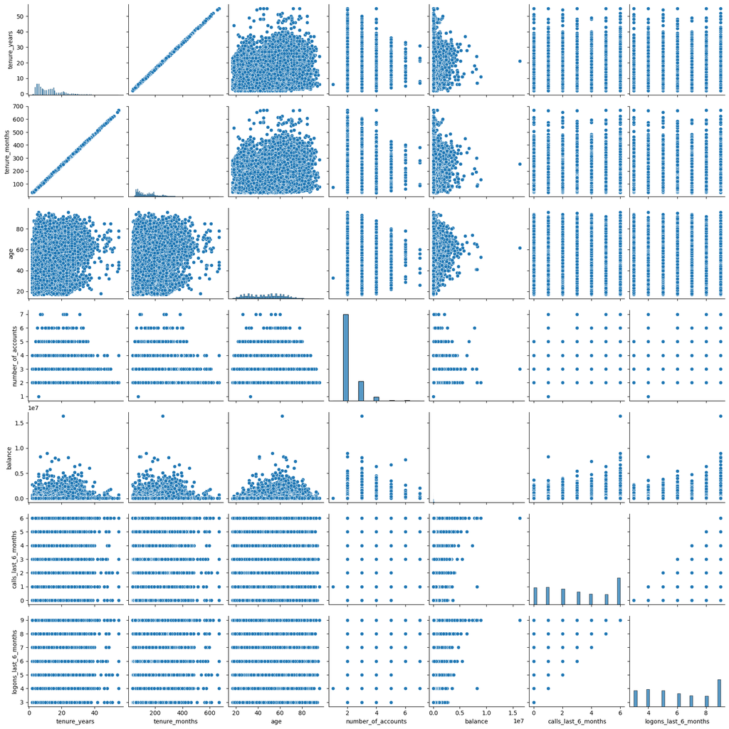

```python
# Create a pairplot
sns.pairplot(df_clients_tested[numerical_columns])
plt.show()
```

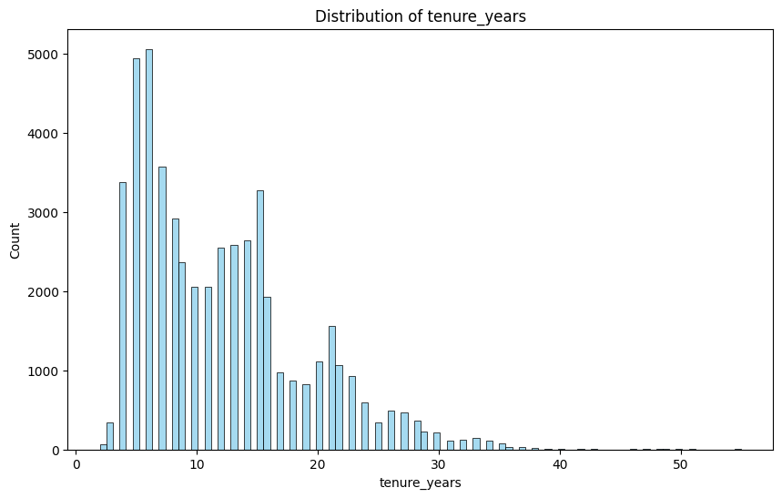

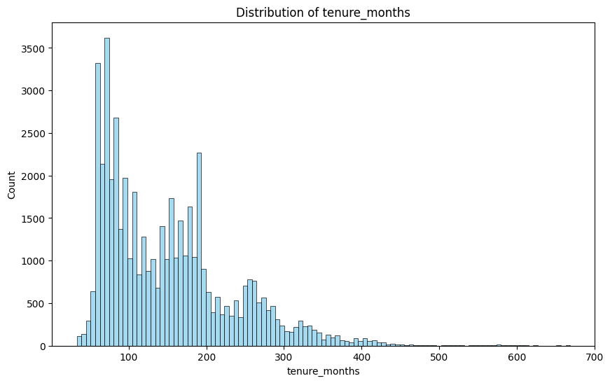

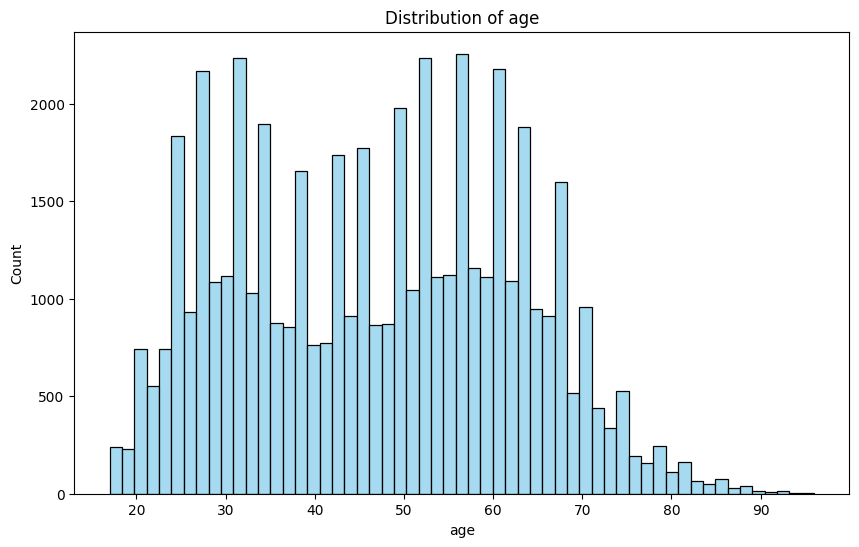

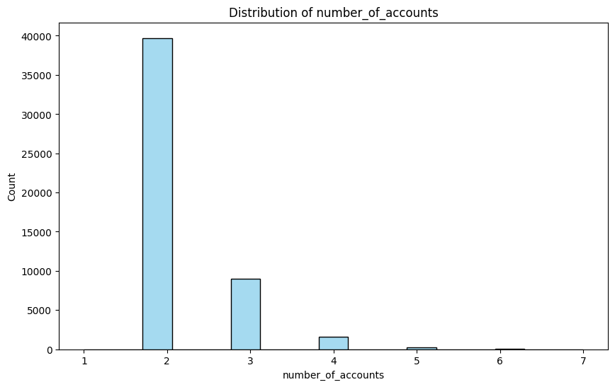

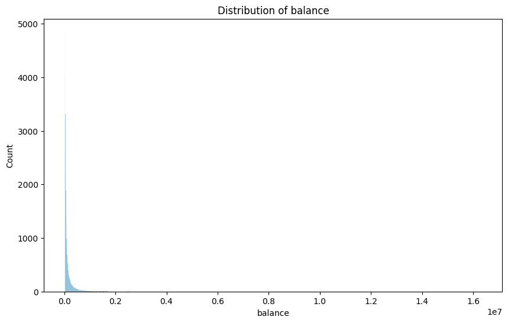

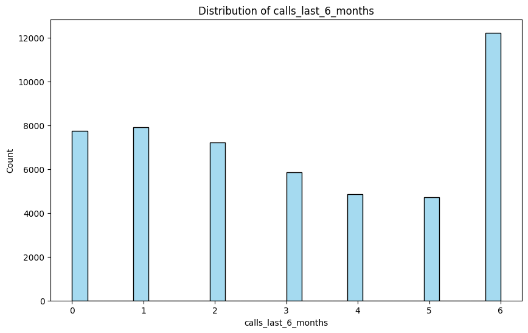

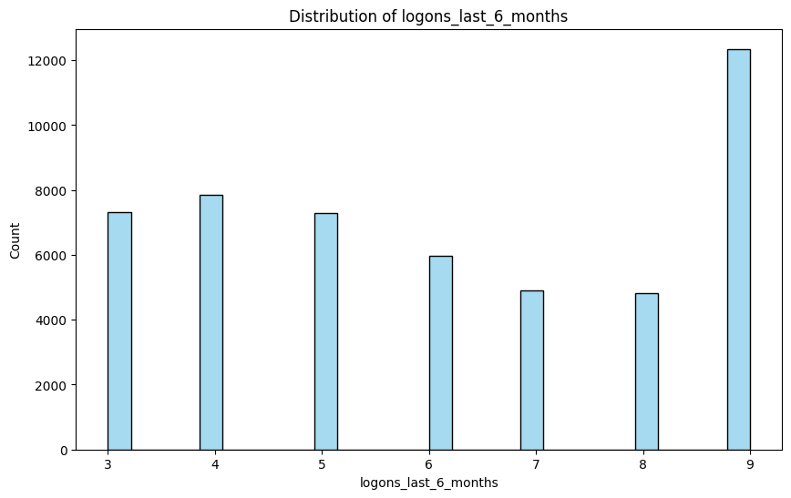

```python
# Distribution plots for numerical variables
numerical_columns = ['tenure_years', 'tenure_months', 'age', 'number_of_accounts', 'balance', 'calls_last_6_months', 'logons_last_6_months']
for column in numerical_columns:
    plt.figure(figsize=(10, 6))
    sns.histplot(df_clients_tested[column], color='skyblue')
    plt.title(f'Distribution of {column}')
    plt.show()
```

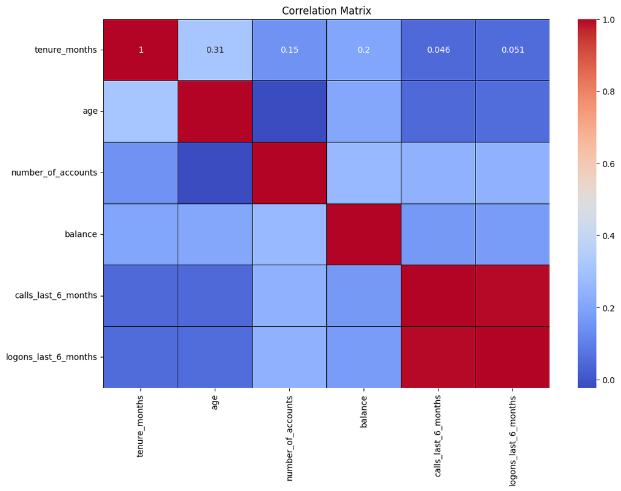

```python
# Correlation matrix among columns
numerical_columns.remove('tenure_years') # Removing tenure_years because it tells me the same thing as tenure_months
correlation_matrix = df_clients_tested[numerical_columns].corr()
plt.figure(figsize=(12, 8))
sns.heatmap(correlation_matrix, annot=True, cmap='coolwarm',linewidths=0.5, linecolor='black')
plt.title('Correlation Matrix')
plt.show()
```

```python
# Printing the correlation matrix
correlation_matrix
```

|  | tenure_months | age | number_of_accounts | balance | calls_last_6_months | logons_last_6_months |
| --- | --- | --- | --- | --- | --- | --- |
| tenure_months | 1.000000 | 0.311356 | 0.148261 | 0.203934 | 0.046081 | 0.050823 |
| age | 0.311356 | 1.000000 | -0.022764 | 0.207058 | 0.047788 | 0.056666 |
| number_of_accounts | 0.148261 | -0.022764 | 1.000000 | 0.265916 | 0.237022 | 0.241447 |
| balance | 0.203934 | 0.207058 | 0.265916 | 1.000000 | 0.168387 | 0.175318 |
| calls_last_6_months | 0.046081 | 0.047788 | 0.237022 | 0.168387 | 1.000000 | 0.994447 |
| logons_last_6_months | 0.050823 | 0.056666 | 0.241447 | 0.175318 | 0.994447 | 1.000000 |

#### Tenure Months and Other Variables:

- Tenure months has a positive correlation with age (0.311), number of accounts (0.148), balance (0.204), calls last 6 months (0.046), and logons last 6 months (0.051).
- The correlations with age, number of accounts, and balance are moderate, indicating that as tenure months increase, these variables tend to increase as well, but not very strongly.
- The correlations with calls last 6 months and logons last 6 months are weak, suggesting a slight positive relationship.

#### Number of Accounts and Other Variables:

- Number of accounts has a positive correlation with balance (0.266), calls last 6 months (0.237), and logons last 6 months (0.241).
- These correlations are moderate, indicating that as the number of accounts increases, balance, calls last 6 months, and logons last 6 months also tend to increase, but not very strongly.

#### Balance and Other Variables:

- Balance has a positive correlation with tenure months (0.204), age (0.207), and number of accounts (0.266).
- These correlations are moderate, suggesting that as balance increases, tenure months, age, and number of accounts also tend to increase, but not very strongly.

#### Calls Last 6 Months and Logons Last 6 Months:

- Calls last 6 months and logons last 6 months have a very strong positive correlation (0.994), indicating that they are almost perfectly linearly related.

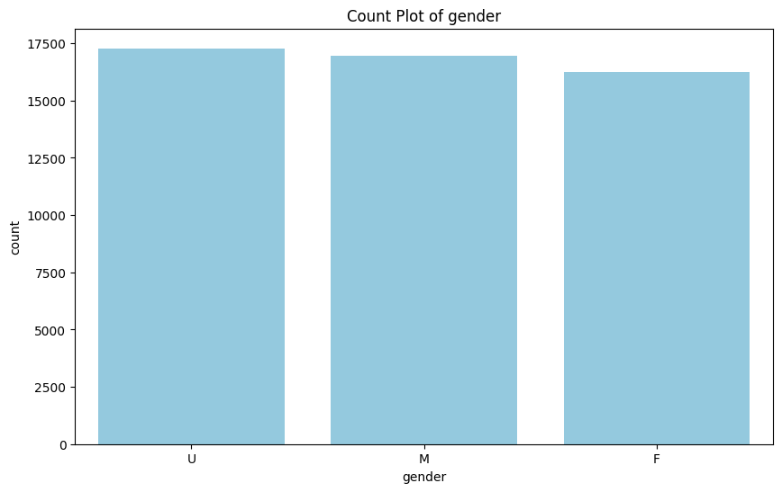

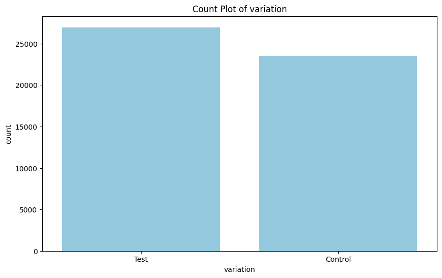

```python
# Count plots for categorical variables
categorical_columns = ['gender', 'variation']
for column in categorical_columns:
    plt.figure(figsize=(10, 6))
    sns.countplot(x=df_clients_tested[column], color = 'skyblue')
    plt.title(f'Count Plot of {column}')
    plt.show()
```

```python
# Calculate percentages for 'gender' column
gender_counts = df_clients_tested['gender'].value_counts(normalize=True) * 100
gender_percentages = pd.DataFrame(gender_counts).reset_index()
gender_percentages.columns = ['Gender', 'Percentage']
print("Gender Distribution Percentage:")
print(gender_percentages)

# Calculate percentages for 'Variation' column
variation_counts = df_clients_tested['variation'].value_counts(normalize=True) * 100
variation_percentages = pd.DataFrame(variation_counts).reset_index()
variation_percentages.columns = ['variation', 'Percentage']
print("\nVariation Distribution Percentage:")
print(variation_percentages)
```

```
Gender Distribution Percentage:
  Gender  Percentage
0      U   34.229916
1      M   33.566392
2      F   32.203692

Variation Distribution Percentage:
  variation  Percentage
0      Test   53.400808
1   Control   46.599192
```

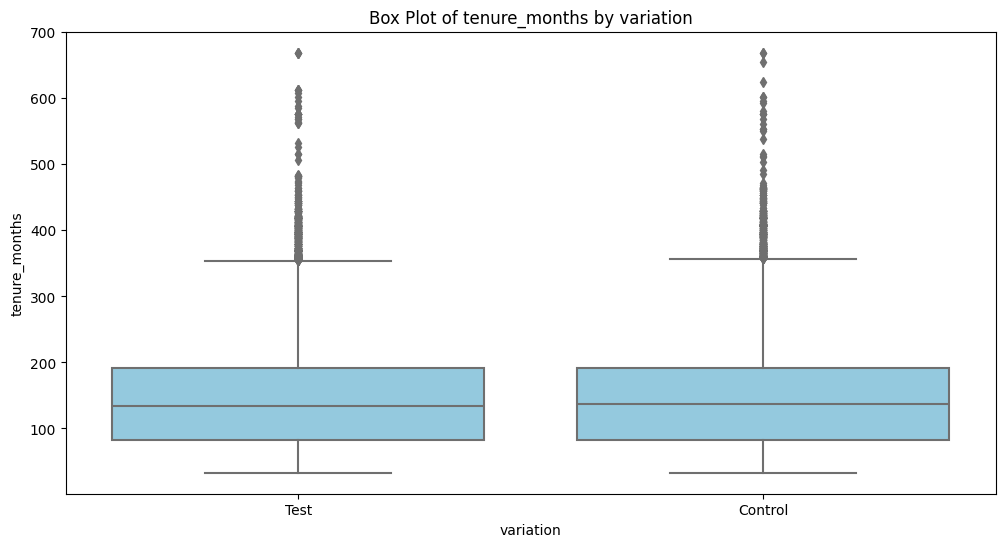

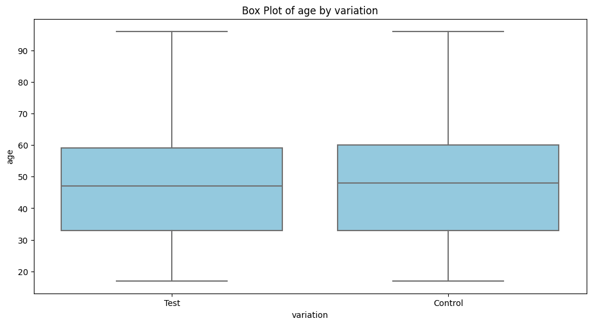

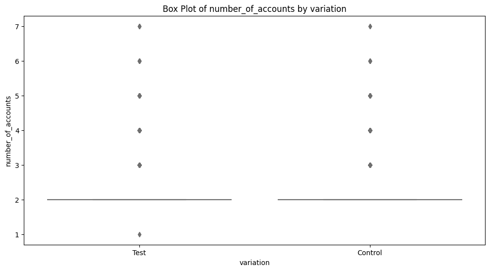

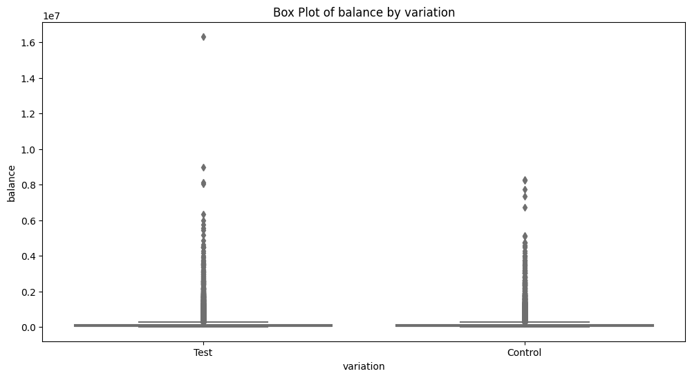

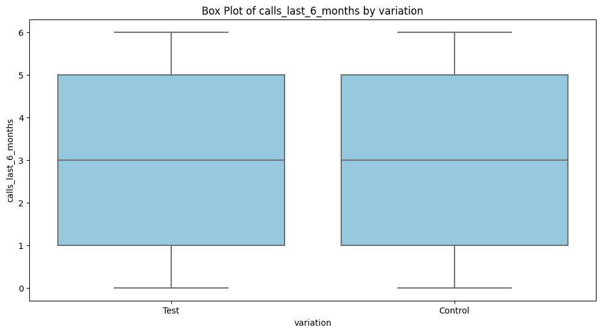

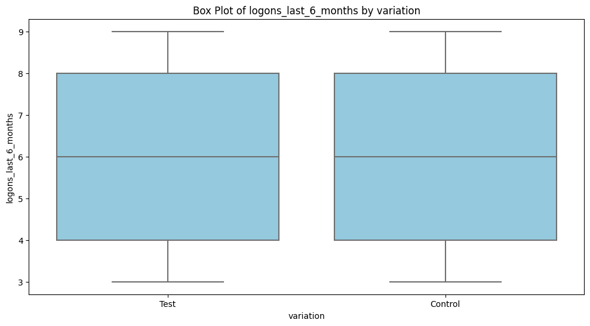

```python
# Box plots to compare numerical variables across the variation categories
for column in numerical_columns:
    plt.figure(figsize=(12, 6))
    sns.boxplot(x='variation', y=column, data=df_clients_tested, color='skyblue')
    plt.title(f'Box Plot of {column} by variation')
    plt.show()
```

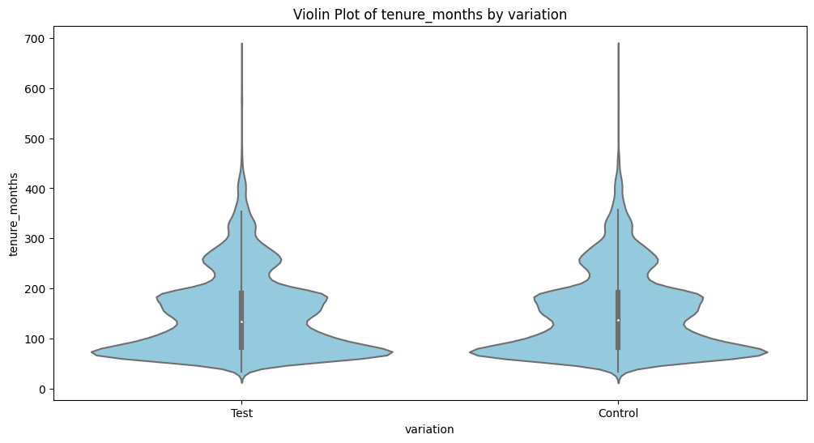

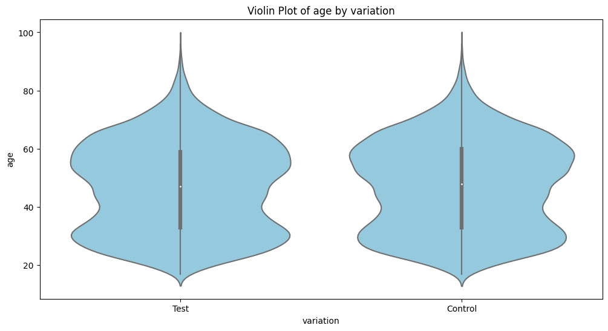

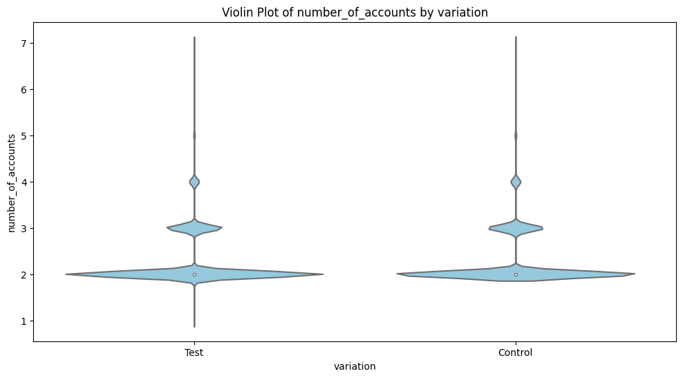

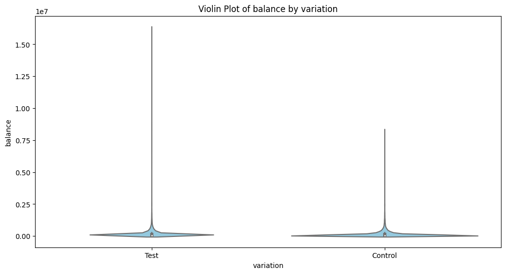

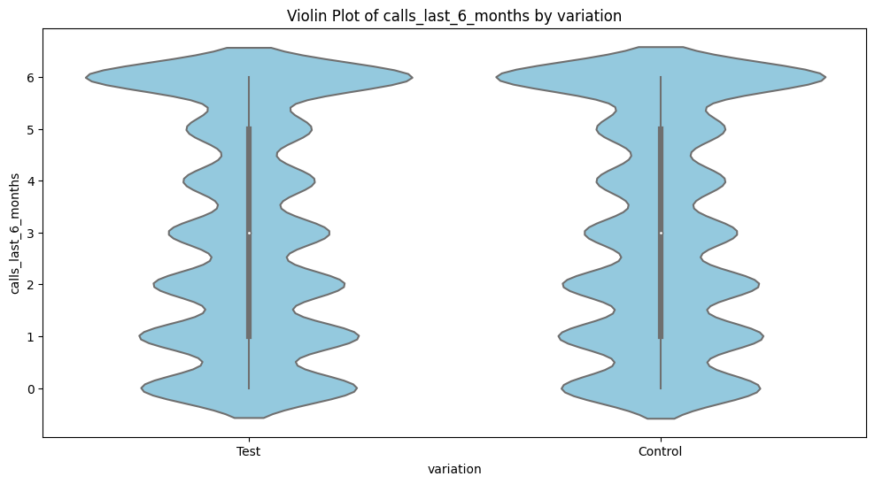

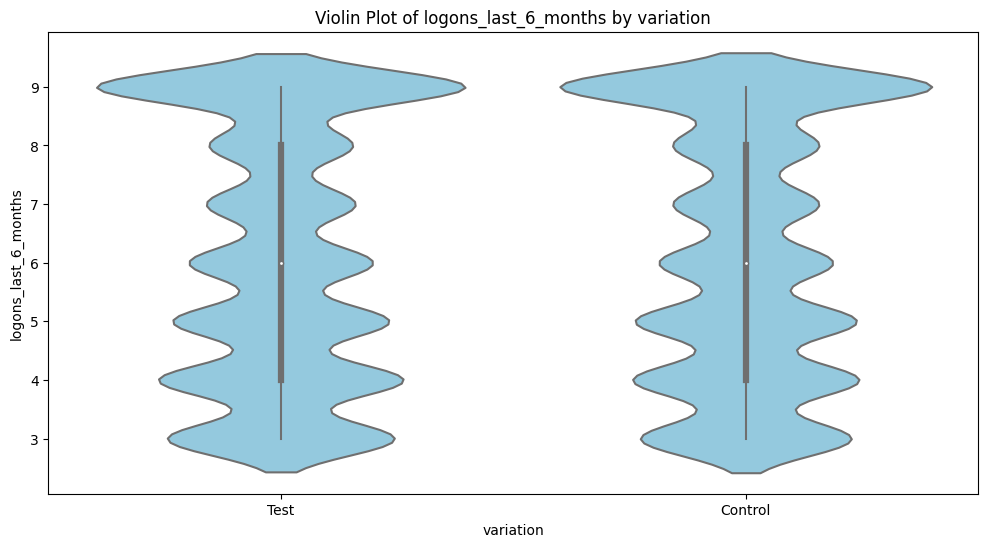

```python
# Violing plots to compare numerical variables distributions across the variation categories
for column in numerical_columns:
    plt.figure(figsize=(12, 6))
    sns.violinplot(x='variation', y=column, data=df_clients_tested, color='skyblue')
    plt.title(f'Violin Plot of {column} by variation')
    plt.show()
```

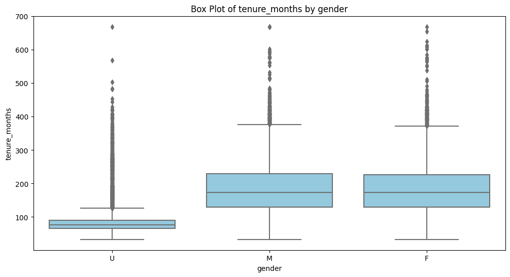

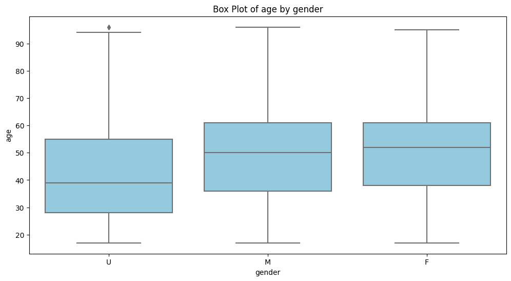

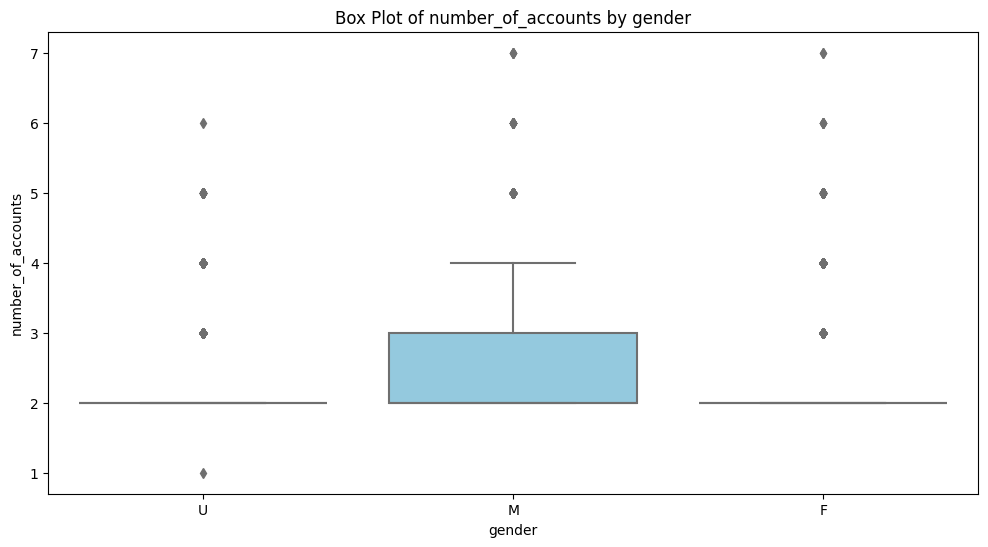

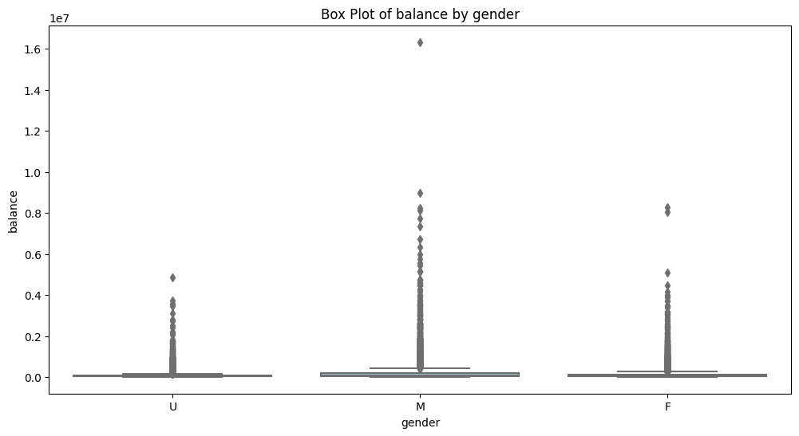

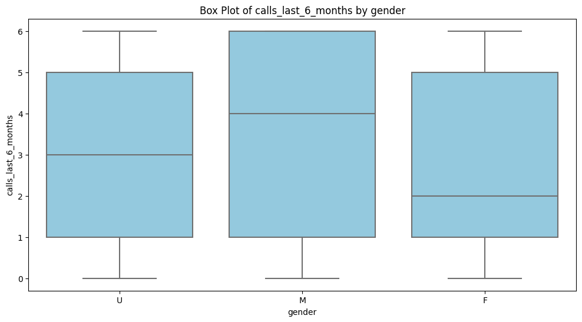

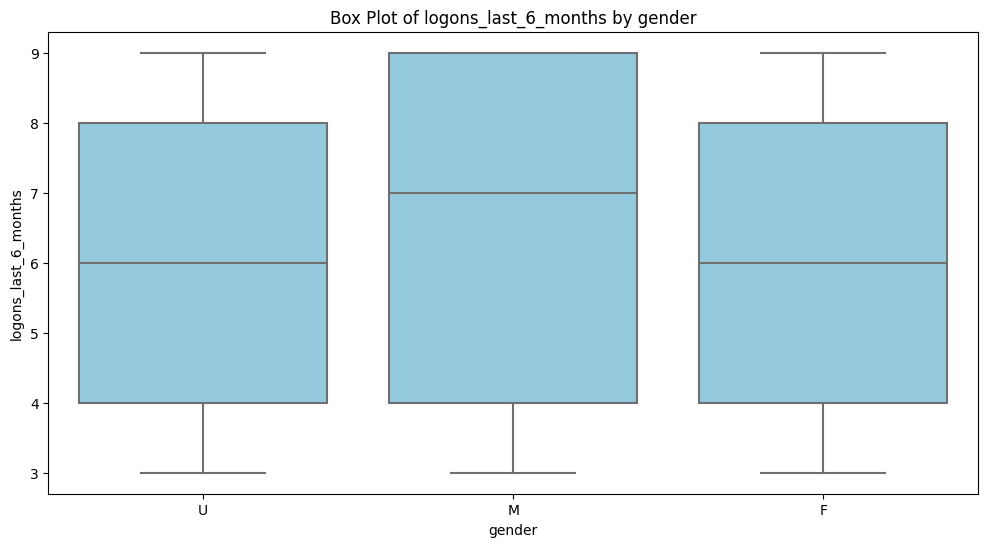

```python
# Box plots to compare numerical variables across the gender categories
for column in numerical_columns:
    plt.figure(figsize=(12, 6))
    sns.boxplot(x='gender', y=column, data=df_clients_tested, color='skyblue')
    plt.title(f'Box Plot of {column} by gender')
    plt.show()
```